# Lesson 04: Probability

27 August, 2018

## 1.) Shoppers

- **Dataset**: *shoppers.csv*

```
## Observations: 50
## Variables: 1
## $ Spending <dbl> 2.32, 6.61, 6.90, 8.04, 9.45, 10.26, 11.34, 11.63, 12...
```

Assume the fifty shoppers exit the store individually in random order.

### a.)

> If one shopper is picked at random, what is the probability of picking a shopper who spent $40 or more dollars? What is the probability of picking a shopper who spent less than $10?

```r
n <- length(shoppers$Spending)

gte_40 <- sum(shoppers$Spending >= 40)
gte_40 / n
```

```
## [1] 0.16
```

```r
lt_10 <- sum(shoppers$Spending < 10)
lt_10 / n
```

```
## [1] 0.1
```

### b.)

> If two shoppers are picked at random, what is the probability the pair will include a shopper who spent $40 or more dollars and one who spent less than $10?

```r
gte_40 * lt_10 / ( n * ( n - 1 ) / 2 )
```

```
## [1] 0.03265306
```

*Hint : For parts c) and d) it will be necessary to assume sampling without replacement.*

### c.)

> If two shoppers are picked at random, what is the probability the pair will include two shoppers who spent no less than $10 and no more than $40?

```r
m <- sum( (shoppers$Spending >= 10) & (shoppers$Spending <= 40))

m * (m - 1) / ( n * (n - 1) )
```

```
## [1] 0.5436735
```

### d.)

> If four shoppers are picked at random, what is the probability one shopper will have spent less than $10, one shopper will have spent $40 or more dollars and two shoppers will have spent no less than $10 and no more than $40?

```r
successful_combinations <- gte_40 * lt_10 * m * (m - 1) / 2
total_combinations <- dim( combn( n, 4 ) )[ 2 ]

successful_combinations / total_combinations
```

```
## [1] 0.1156752
```

### e.)

> If we know a randomly picked shopper has spent more than $30, what is the probability that shopper has spent more than $40?

```r
g1 <- sum(shoppers$Spending > 30)
g2 <- sum(shoppers$Spending > 40)

g2 / g1
```

```
## [1] 0.4705882
```

## 2.) R Sampling

Use R to answer these questions

### a.)

- Draw 100 samples with replacement of size 22 from the 365 integers (i.e. 1,2,.,365).
- Count the number of samples in which one or more of the numbers sampled is duplicated.
- Divide by 100 to estimate the probability of such duplication occurring.
- (If 22 people are selected at random, what is the probability of two or more matching birthdays?)

```r
integers <- seq( from = 1, to = 365, by = 1 )

set.seed(1234) # fix the sampling as to reproduce

samples <- replicate( 100, sample(integers, 22, replace = TRUE))

dupes <- apply(samples, 2, function(x) {
    length(x) != length(unique(x))
})

sum(dupes) / 100
```

```
## [1] 0.53
```

### b.)

*Suppose that 60% of marbles in a bag are black and 40% are white.*

- Generate a random sample of size 20 with replacement using uniform random numbers.
- For the numbers in each sample, if a random number is 0.6 or less, code it as a 1. If it is not 0.6 or less code it a zero.
- Add the twenty coded numbers.

```r
population_size <- 50

gen_marbles <- function() {
    sample <- sample(runif(population_size), size = 20, replace = T)
    coded <- ifelse( sample <= .6, 1, 0 )

    sum(coded)
}

num_results <- function(trials, value = 11) {
    simulations <- replicate(trials, gen_marbles() )

    hist(simulations,
        breaks = pretty(simulations),
        col = "red",
        main = paste("Expected Value:", sum(simulations) / trials))

    sum(simulations >= value)
}
```

Do this 50 times and calculate the proportion of times the sum is 11 or greater.

```r
    runs <- 50
    results <- num_results(runs)
```

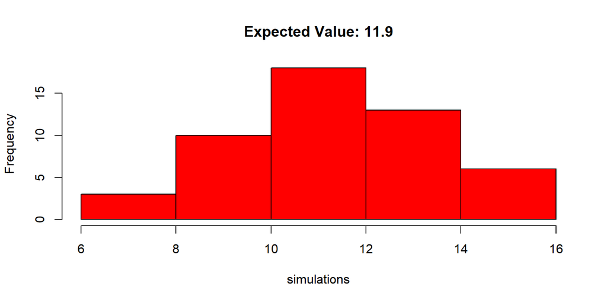

```r
    results / runs # probability
```

```
## [1] 0.74
```

What have you estimated? Expand the number of trials to 10,000.

```r
    runs <- 10000
    results <- num_results(runs)
```

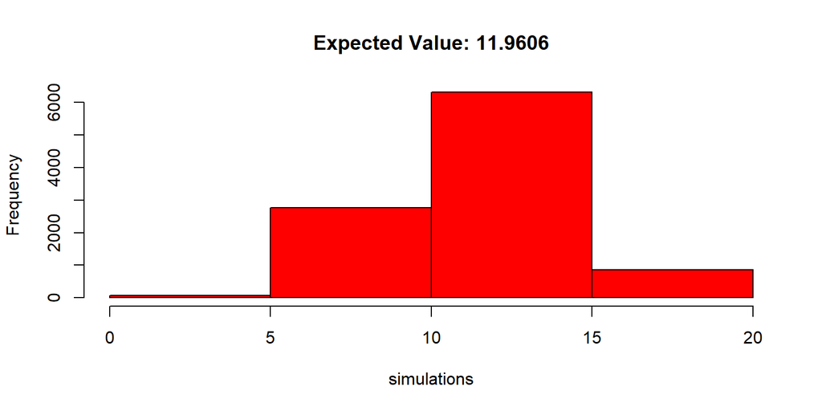

```r
    results / runs # probability
```

```
## [1] 0.7177
```

The exact binomial estimated probability is 0.755 and the expectation is 12.